# Project 2 Data Summaries

The following tables summarize data collected in REDCap for PAN Project 2.

Report Date: **Jan 08, 2025**

#### Participants with HML IDs

These participants are in the MC Demographics form and have been assigned HML IDs.

|  | Atlanta (N=198) | Baltimore (N=154) | Miami (N=161) | Tucson (N=223) | Overall (N=736) |
| --- | --- | --- | --- | --- | --- |
| Sex |  |  |  |  |  |
| Female | 135 (68.2%) | 106 (68.8%) | 122 (75.8%) | 145 (65.0%) | 508 (69.0%) |
| Male | 63 (31.8%) | 48 (31.2%) | 38 (23.6%) | 78 (35.0%) | 227 (30.8%) |
| Missing | 0 (0%) | 0 (0%) | 1 (0.6%) | 0 (0%) | 1 (0.1%) |
| Age |  |  |  |  |  |
| 49 | 1 (0.5%) | 0 (0%) | 0 (0%) | 0 (0%) | 1 (0.1%) |
| 50-59 | 52 (26.3%) | 49 (31.8%) | 51 (31.7%) | 72 (32.3%) | 224 (30.4%) |
| 60-69 | 90 (45.5%) | 61 (39.6%) | 75 (46.6%) | 92 (41.3%) | 318 (43.2%) |
| 70-79 | 55 (27.8%) | 44 (28.6%) | 35 (21.7%) | 59 (26.5%) | 193 (26.2%) |
| Race |  |  |  |  |  |
| Hispanic/Latino | 10 (5.1%) | 1 (0.6%) | 51 (31.7%) | 45 (20.2%) | 107 (14.5%) |
| Non-Hispanic Black | 45 (22.7%) | 65 (42.2%) | 24 (14.9%) | 7 (3.1%) | 141 (19.2%) |
| Non-Hispanic White | 137 (69.2%) | 83 (53.9%) | 80 (49.7%) | 165 (74.0%) | 465 (63.2%) |
| Other | 6 (3.0%) | 5 (3.2%) | 6 (3.7%) | 6 (2.7%) | 23 (3.1%) |
| Consent Uploaded? |  |  |  |  |  |
| Consented | 170 (85.9%) | 99 (64.3%) | 134 (83.2%) | 194 (87.0%) | 597 (81.1%) |
| Non-Consented | 28 (14.1%) | 55 (35.7%) | 27 (16.8%) | 29 (13.0%) | 139 (18.9%) |

#### Consented Participants

The following table contains only participants whose consent has been uploaded to REDCap. The rest of this report follows these participants.

|  | Atlanta (N=170) | Baltimore (N=99) | Miami (N=134) | Tucson (N=194) | Overall (N=597) |
| --- | --- | --- | --- | --- | --- |
| Sex |  |  |  |  |  |
| Female | 112 (65.9%) | 72 (72.7%) | 100 (74.6%) | 125 (64.4%) | 409 (68.5%) |
| Male | 58 (34.1%) | 27 (27.3%) | 33 (24.6%) | 69 (35.6%) | 187 (31.3%) |
| Missing | 0 (0%) | 0 (0%) | 1 (0.7%) | 0 (0%) | 1 (0.2%) |
| Age |  |  |  |  |  |
| 49 | 1 (0.6%) | 0 (0%) | 0 (0%) | 0 (0%) | 1 (0.2%) |
| 50-59 | 39 (22.9%) | 31 (31.3%) | 44 (32.8%) | 57 (29.4%) | 171 (28.6%) |
| 60-69 | 83 (48.8%) | 42 (42.4%) | 60 (44.8%) | 82 (42.3%) | 267 (44.7%) |
| 70-79 | 47 (27.6%) | 26 (26.3%) | 30 (22.4%) | 55 (28.4%) | 158 (26.5%) |
| Race |  |  |  |  |  |
| Hispanic/Latino | 8 (4.7%) | 0 (0%) | 42 (31.3%) | 40 (20.6%) | 90 (15.1%) |
| Non-Hispanic Black | 37 (21.8%) | 42 (42.4%) | 17 (12.7%) | 5 (2.6%) | 101 (16.9%) |
| Non-Hispanic White | 120 (70.6%) | 54 (54.5%) | 72 (53.7%) | 144 (74.2%) | 390 (65.3%) |
| Other | 5 (2.9%) | 3 (3.0%) | 3 (2.2%) | 5 (2.6%) | 16 (2.7%) |

There are 2 participants without uploaded consents, but still have data collected in other REDCap forms. 1 of these have a “Main Consent Date” in the Consent form:

| Area | Record ID | HML ID | Main Consent Date | Main Consent Uploaded |
| --- | --- | --- | --- | --- |
| Tucson | 516 | HML0528 | 2024-07-31 | Missing |
| Miami | 664 | HML0680 | Missing | Missing |

I have removed those participants from the rest of this report.

### Cognitive Testing and Biometrics

This table summarizes the cognitive testing in Scored Forms and the Biometrics Survey Status from the Experimental Tasks form. Participants without any missing form data are marked as “Non-Missing”, if they have at least one missing entry then they are marked as “Missing.”

|  | Atlanta (N=170) | Baltimore (N=99) | Miami (N=134) | Tucson (N=194) | Overall (N=597) |
| --- | --- | --- | --- | --- | --- |
| PHQ-9 |  |  |  |  |  |
| Non-Missing | 170 (100%) | 99 (100%) | 134 (100%) | 194 (100%) | 597 (100%) |
| Missing | 0 (0%) | 0 (0%) | 0 (0%) | 0 (0%) | 0 (0%) |
| MoCA |  |  |  |  |  |
| Non-Missing | 170 (100%) | 99 (100%) | 134 (100%) | 194 (100%) | 597 (100%) |
| Missing | 0 (0%) | 0 (0%) | 0 (0%) | 0 (0%) | 0 (0%) |
| NAART |  |  |  |  |  |
| Non-Missing | 170 (100%) | 99 (100%) | 134 (100%) | 194 (100%) | 597 (100%) |
| Missing | 0 (0%) | 0 (0%) | 0 (0%) | 0 (0%) | 0 (0%) |
| AVLT |  |  |  |  |  |
| Non-Missing | 169 (99.4%) | 99 (100%) | 133 (99.3%) | 193 (99.5%) | 594 (99.5%) |
| Missing | 1 (0.6%) | 0 (0%) | 1 (0.7%) | 1 (0.5%) | 3 (0.5%) |
| Biometrics Form |  |  |  |  |  |
| Non-Missing | 146 (85.9%) | 96 (97.0%) | 129 (96.3%) | 191 (98.5%) | 562 (94.1%) |
| Missing | 24 (14.1%) | 3 (3.0%) | 5 (3.7%) | 3 (1.5%) | 35 (5.9%) |
| Overall |  |  |  |  |  |
| Complete Neuropsych and Biometrics | 146 (85.9%) | 96 (97.0%) | 128 (95.5%) | 190 (97.9%) | 560 (93.8%) |
| Incomplete Neuropsych and Biometrics | 24 (14.1%) | 3 (3.0%) | 6 (4.5%) | 4 (2.1%) | 37 (6.2%) |

#### Participants marked as ineligible or dropped from the study:

IDs dropped from the study:

| HML ID | REDCap ID | Area | Eligible for Behavior? | Eligible for MRI? | Eligible for Blood Draw? |
| --- | --- | --- | --- | --- | --- |
| HML0114 | 77 | Miami | Yes | No | Yes |
| HML0180 | 170 | Miami | Yes | No | Yes |
| HML0453 | 451 | Atlanta | Yes | No | Yes |

#### Data Flowchart

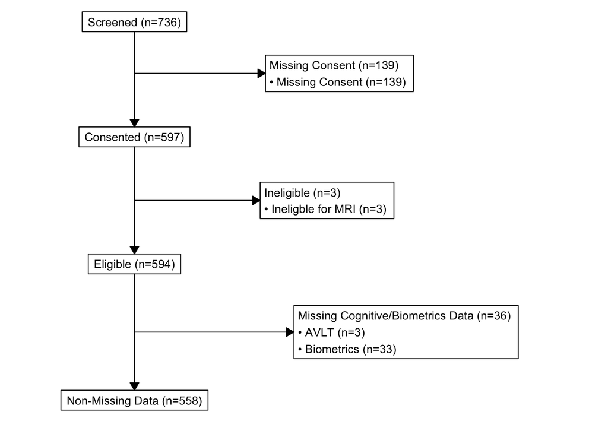